# P8106_stl2137_HW2

The response variable is the out-of-state tuition (Outstate).

```r
school_dat <- read_csv("./College.csv") %>%
  janitor::clean_names()
school_no_columbia_dat <- school_dat[-125,]
```

## Part A

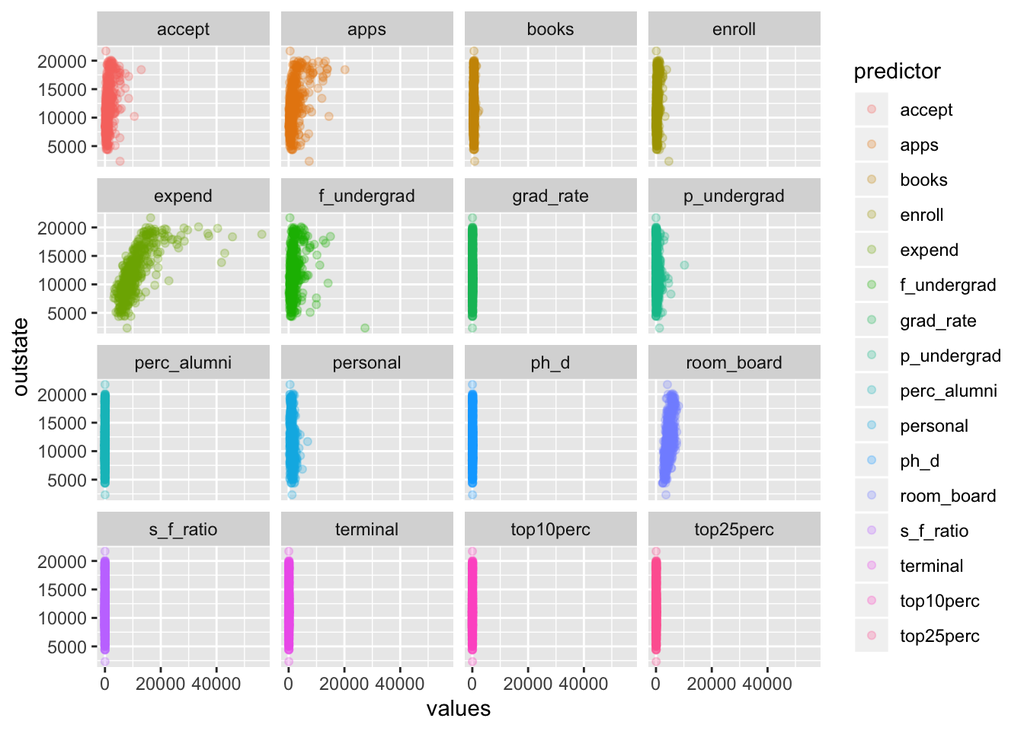

```r
predictors_df <- school_no_columbia_dat %>%
  select(outstate, everything()) %>%
  group_by(college) %>%
  pivot_longer(
    apps:grad_rate,
    names_to = "predictor",
    values_to = "values"
  )

### Tidyverse plotting

predictors_df %>%
  ggplot(
    aes(x = values, y = outstate, color = predictor)
  ) +
  geom_point(alpha = 0.25) +
  facet_wrap(. ~ predictor, ncol = 4)
```

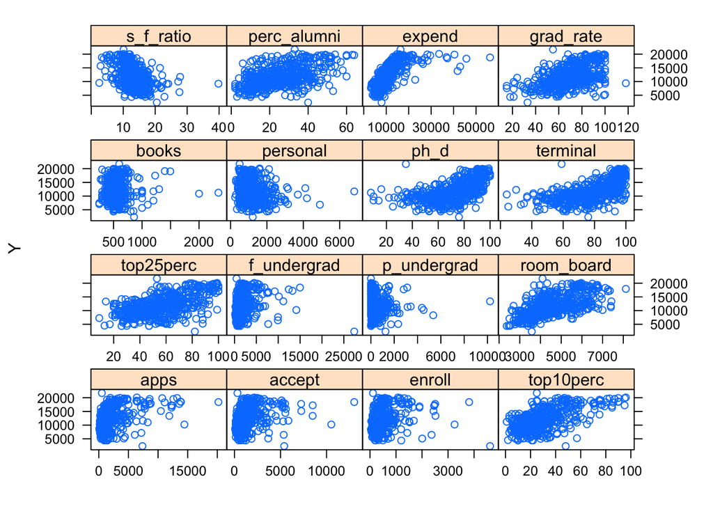

```r
### Using base R plotting
# matrix of predictors
school_no_columbia_dat <- school_no_columbia_dat[-1]

x <- model.matrix(outstate~.,school_no_columbia_dat)[,-1]
y <- school_no_columbia_dat$outstate

featurePlot(x, y, plot = "scatter", labels = c("","Y"),
            type = c("p"), layout = c(4,4))
```

## Part B

Describe the results obtained.

```r
smooth_spline_fit <- smooth.spline(school_no_columbia_dat$terminal, school_no_columbia_dat$outstate)
smooth_spline_fit$df
```

```
## [1] 4.468629
```

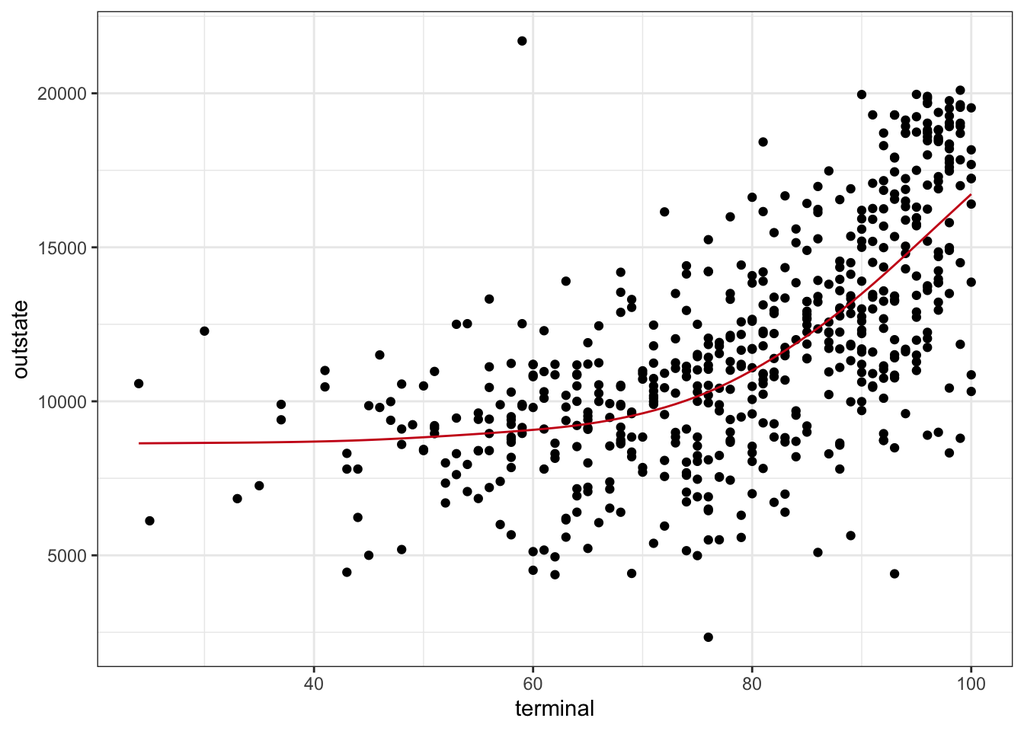

```r
terminal_lims <- range(school_no_columbia_dat$terminal)
terminal_grid <- seq(from = terminal_lims[1], to = terminal_lims[2])

pred_smooth <- predict(smooth_spline_fit,
                       x = terminal_grid)

pred_sspline_df <- data.frame(pred = pred_smooth$y,
                             terminal = terminal_grid)

p <- ggplot(data = school_no_columbia_dat,
            aes(
              x = terminal,
              y = outstate
            )) + geom_point() + theme_bw()

p + geom_line(
  aes(
    x = terminal,
    y = pred),
  data = pred_sspline_df,
  color = rgb(.8, .1, .1, 1)) + theme_bw()
```

From the smoothing spline model, we are able to assertain that the degree of freedoms is 4.4686294. From the plot `p`, we can see that there is a non-linear trend between out-of-state tuition and the percentage of faculty with a terminal degree. The smoothing spline, represented by the red line, shows that the prediction of the smoothing spline fits the data.

## Part C

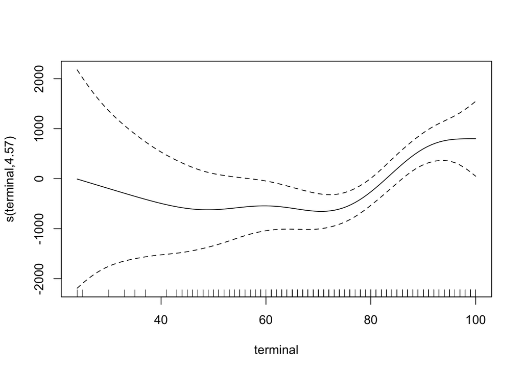

```r
gam_school_1 <- gam(outstate ~ apps + accept + enroll + top10perc + top25perc + f_undergrad + p_undergrad + room_board + books + personal + ph_d + s(terminal) + s_f_ratio + perc_alumni + expend + grad_rate, data = school_no_columbia_dat)

plot(gam_school_1)
```

```r
### To check residuals
#gam.check(gam_school_1)
```

From the plot, we can see that when the percentage of faculty members with a terminal degree hits 80%, the out-of-state tutition costs look to increase/cost more. Prior to 80% of faculty members with a terminal degree, the out-of-state costs look to be lower/cost less.

## Part D

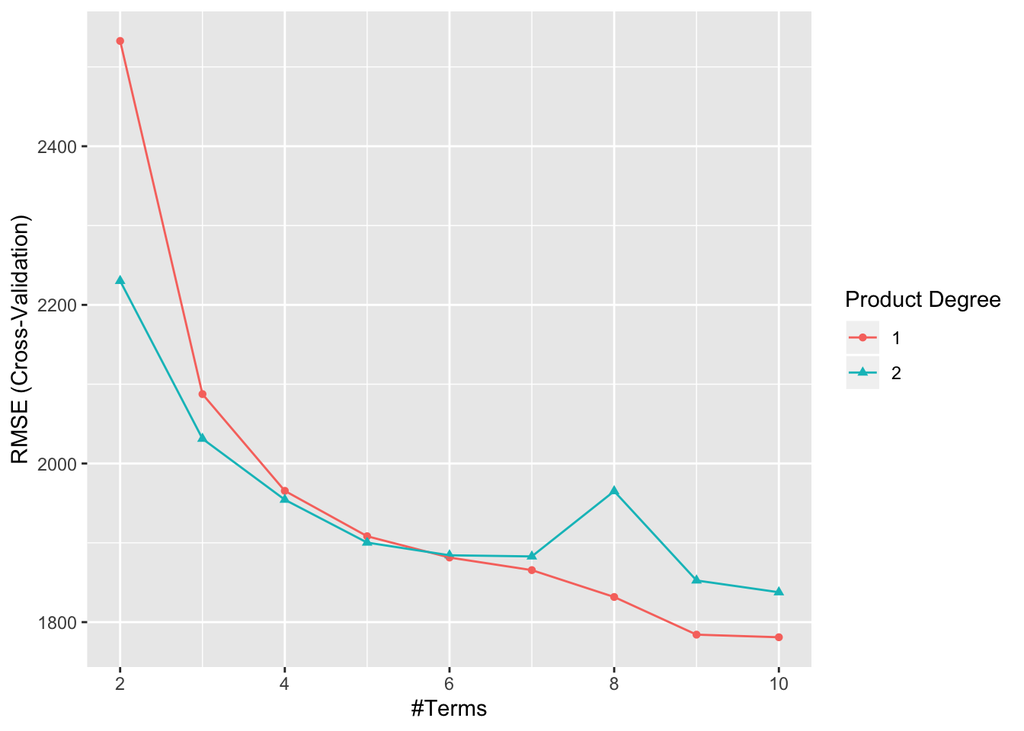

```r
mars_grid <- expand.grid(degree = 1:2,
                         nprune = 2:10)

control1 <- trainControl(method = "cv", number = 10)

set.seed(1)
mars_fit <- train(x, y,
                  method = "earth",
                  tuneGrid = mars_grid,
                  trControl = control1)

ggplot(mars_fit)
```

```r
mars_fit$bestTune
```

```
##   nprune degree
## 9     10      1
```

```r
coef(mars_fit$finalModel)
```

```
##         (Intercept)     h(expend-15365)  h(4450-room_board)
##       10856.8275542          -0.7836173          -1.4272043
## h(f_undergrad-1355) h(1355-f_undergrad)   h(22-perc_alumni)
##          -0.3818847          -1.6799143        -105.5570689
##        h(apps-3712)       h(913-enroll)      h(2193-accept)
##           0.4334737           4.5019587          -1.9769988
##      h(expend-6881)
##           0.7774546
```

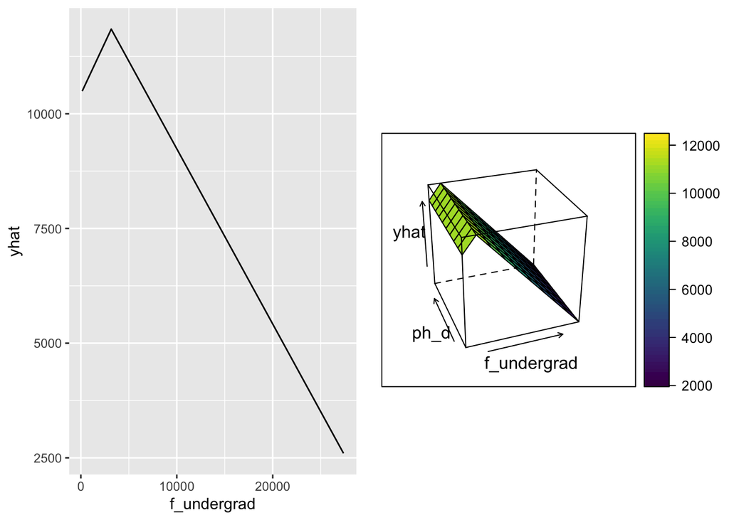

```r
partial_school_1 <- partial(mars_fit, pred.var = c("f_undergrad"), grid.resolution = 10) %>% autoplot()

partial_school_2 <- partial(mars_fit, pred.var = c("f_undergrad", "ph_d"), grid.resolution = 10) %>%
      plotPartial(levelplot = FALSE, zlab = "yhat", drape = TRUE,
                  screen = list(z = 20, x = -60))

grid.arrange(partial_school_1, partial_school_2, ncol = 2)
```

## Part E

```r
### Grabbing Columbia observation
columbia_dat <- school_dat[125,]

columbia_gam <- predict(gam_school_1, newdata = columbia_dat)

columbia_mars <- as.numeric(predict(mars_fit, newdata = columbia_dat))
```

Based off the GAM model, we predict that the out-of-state tuition at Columbia University is 1.940671310^{4}. Based off the MARS model, we predict that the out-of-state tuition at Columbia University is 1.746990410^{4}. Between the two models, the GAM model predicts the out-of-state tuition for Columbia to be higher by 1936.8090809 compared to MARS model.